# Sistema de Recomendação Para Rede de Varejo

Autor: Stefani Ramalho

Projeto: Data Science Academy

Conjuntos de dados: [www.instacart.com](https://www.instacart.com/datasets/grocery-shopping-2017)

## Market Basket Analysis

Sistema de recomendacao para prever quais produtos adquiridos anteriormente estarão no próximo pedido de um usuário.

### 1 - Introdução

Quer você faça compras com listas de compras meticulosamente planejadas ou deixe que o capricho guie seus passos, nossos rituais únicos de compra definem quem somos. Instacart, um aplicativo de pedido e entrega de supermercado, tem como objetivo facilitar o preenchimento de sua geladeira e despensa com seus itens pessoais favoritos e itens básicos quando você precisar deles. Depois de selecionar produtos por meio do aplicativo Instacart, os compradores revisam seus pedidos, fazem compras e a entrega é feita na loja mais próxima a você.

A equipe de ciência de dados da Instacart desempenha um papel importante no fornecimento dessa experiência de compra agradável. Atualmente, eles usam dados transacionais para desenvolver modelos que preveem quais produtos um usuário comprará novamente, quais tentará pela primeira vez ou quais adicionará ao carrinho durante uma sessão.

### 2 - Carregando os módulos e visualizando os dados

```r
# Importando os modulos
library(data.table)
library(tidyverse)
#install.packages('fastDummies')
library(fastDummies)
library(plotrix)
library(scales)
library(gridExtra)
#install.packages('arules')
library(arules)

# Lendo os conjuntos de dados
order_train <- fread('dados/order_products__train.csv')
order_prior <- fread('dados/order_products__prior.csv')
```

```
|--------------------------------------------------|
|==================================================|
```

```r
products <- fread('dados/products.csv')
departments <- fread('dados/departments.csv')
aisles <- fread('dados/aisles.csv')
orders <- fread('dados/orders.csv')
```

### orders

- order_id: identificador da ordem
- user_id: identificador do cliente
- eval_set: conjunto de dados a qual este item percente (“prior” “train” “test”)
- order_number: numero da ordem a qual pertence
- order_dow: dia da semana em que foi feita a compra
- order_hour_of_day: a hora do dia em que foi feita a compra
- days_since_prior: dias desde a ultima compra, com limite ate 30 (na = 1)

```r
head(orders)
```

| order_id | user_id | eval_set | order_number | order_dow | order_hour_of_day | days_since_prior_order |
| --- | --- | --- | --- | --- | --- | --- |
| 2539329 | 1 | prior | 1 | 2 | 8 | NA |
| 2398795 | 1 | prior | 2 | 3 | 7 | 15 |
| 473747 | 1 | prior | 3 | 3 | 12 | 21 |
| 2254736 | 1 | prior | 4 | 4 | 7 | 29 |
| 431534 | 1 | prior | 5 | 4 | 15 | 28 |
| 3367565 | 1 | prior | 6 | 2 | 7 | 19 |

### products

- product_id: identificador do produto
- product_name: nome do produto
- aisle_id: identificador do corredor
- department_id: identificador do departamento

```r
head(products)
```

| product_id | product_name | aisle_id | department_id |
| --- | --- | --- | --- |
| 1 | Chocolate Sandwich Cookies | 61 | 19 |
| 2 | All-Seasons Salt | 104 | 13 |
| 3 | Robust Golden Unsweetened Oolong Tea | 94 | 7 |
| 4 | Smart Ones Classic Favorites Mini Rigatoni With Vodka Cream Sauce | 38 | 1 |
| 5 | Green Chile Anytime Sauce | 5 | 13 |
| 6 | Dry Nose Oil | 11 | 11 |

### aisles

- aisle_id: identificador
- aisle: nome do corredor

```r
head(aisles)
```

| aisle_id | aisle |
| --- | --- |
| 1 | prepared soups salads |
| 2 | specialty cheeses |
| 3 | energy granola bars |
| 4 | instant foods |
| 5 | marinades meat preparation |
| 6 | other |

### deptartments

- department_id: identifcador do departamento
- department: nome do departamento

```r
head(departments)
```

| department_id | department |
| --- | --- |
| 1 | frozen |
| 2 | other |
| 3 | bakery |
| 4 | produce |
| 5 | alcohol |
| 6 | international |

### order_prior (ordens anteriores)

- order_id: identificador da ordem
- product_id: identificador do produto
- add_to_cart_order: order em que o produto foi adicionado ao carrinho
- reordered: se o produto foi comprado pelo cliente no passado (1: sim - 0: nao)

```r
head(order_prior)
```

| order_id | product_id | add_to_cart_order | reordered |
| --- | --- | --- | --- |
| 2 | 33120 | 1 | 1 |
| 2 | 28985 | 2 | 1 |
| 2 | 9327 | 3 | 0 |
| 2 | 45918 | 4 | 1 |
| 2 | 30035 | 5 | 0 |
| 2 | 17794 | 6 | 1 |

### order_train (dados de treinamento)

- order_id: identificador da ordem
- product_id: identificador do produto
- add_to_cart_order: order em que o produto foi adicionado ao carrinho
- reordered: se o produto foi comprado pelo cliente no passado (1: sim - 0: nao)

```r
head(order_train)
```

| order_id | product_id | add_to_cart_order | reordered |
| --- | --- | --- | --- |
| 1 | 49302 | 1 | 1 |
| 1 | 11109 | 2 | 1 |
| 1 | 10246 | 3 | 0 |
| 1 | 49683 | 4 | 0 |
| 1 | 43633 | 5 | 1 |
| 1 | 13176 | 6 | 0 |

### 3 - Limpeza e tratamento dos dados

Apenas o dataset “Ordes” possui valores ausentes presentates no atributo “days_since_prior_order”. Após verificação no dataset, os valores NA estão presentes no atributo “eval_set” com a categoria “prior”, desta forma o valor da média irá preencher os valroes vazios.

```r
# Funcao para buscar balores NA
valores_na <- function(df){

  dados = sapply(df, function(x){
    sum(is.na(x))
  }) %>%
    data.frame() %>%
    rownames_to_column() %>%
    filter(. > 0)

  names(dados) = c("variavel","NA")
  return(dados)
}

# Buscando por valores missings em todos os datasets
for (dfs in c('aisles', 'departments', 'order_prior', 'order_train', 'orders', 'products')){
  if (any(is.na(get(dfs)))) {
    get(dfs) %>% valores_na() %>% print()
  }
}
```

| variavel | NA |
| --- | --- |
| days_since_prior_order | 206209 |

```r
# removendo valores NA referente ao atributo days_since_prior_order e subistituindo pela media com o eval_sel prior
orders[is.na(orders$days_since_prior_order), 'days_since_prior_order'] = 10
```

Agrupando os datasets products, departments e aisles aos dataset order_train e order_prior, criando um unico conjunto de dados.

```r
# Agrupando os datasets train e prior
dataset <- order_train %>%
  mutate('eval_set' = 'train') %>%
  bind_rows(
    order_prior %>%
    mutate('eval_set' = 'prior')) %>%
  inner_join(products, by = 'product_id') %>%
  inner_join(departments, by = 'department_id') %>%
  inner_join(aisles, by = 'aisle_id')

# removendo os datasets que foram usados no agrupamento
rm(products, departments, aisles, order_train, order_prior)

# Visualisando o dataset final
str(dataset)
```

```
'data.frame':   33819106 obs. of  10 variables:
 $ order_id         : int  1 1 1 1 1 1 1 1 36 36 ...
 $ product_id       : int  49302 11109 10246 49683 43633 13176 47209 22035 39612 19660 ...
 $ add_to_cart_order: int  1 2 3 4 5 6 7 8 1 2 ...
 $ reordered        : int  1 1 0 0 1 0 0 1 0 1 ...
 $ eval_set         : chr  "train" "train" "train" "train" ...
 $ product_name     : chr  "Bulgarian Yogurt" "Organic 4% Milk Fat Whole Milk Cottage Cheese" "Organic Celery Hearts" "Cucumber Kirby" ...
 $ aisle_id         : int  120 108 83 83 95 24 24 21 2 115 ...
 $ department_id    : int  16 16 4 4 15 4 4 16 16 7 ...
 $ department       : chr  "dairy eggs" "dairy eggs" "produce" "produce" ...
 $ aisle            : chr  "yogurt" "other creams cheeses" "fresh vegetables" "fresh vegetables" ...
```

### 4 - Analise exploratoria

Total de itens vendidos de acordo com o eval_sel, sendo a maior parte dos dados do tipo prior.

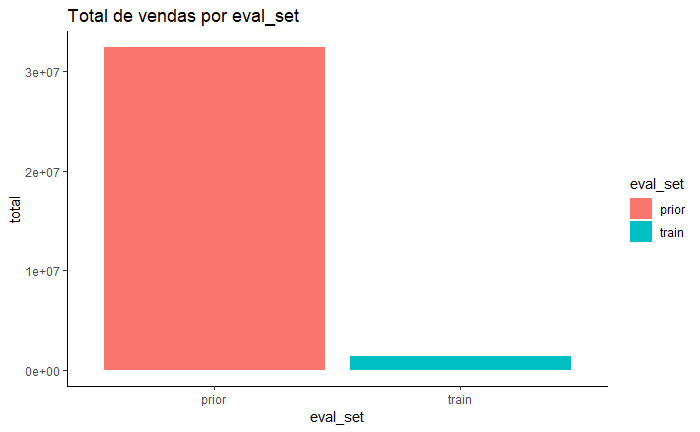

```r
# agrupando os dados por eval_set e criando um atributo para contar o total de itens
dataset %>% group_by(eval_set) %>%
  summarise(total = n()) %>%
  ggplot(aes(x = eval_set, y = total, fill = eval_set)) +
  geom_bar(stat = 'identity') +
  theme_classic() +
  ggtitle("Total de vendas por eval_set")
```

Total de itens vendidos de acordo com o atributo reordered, sendo que a maioria do valores pertencem ao valor 1, ou seja, são produtos que já foram comprados anteriormente.

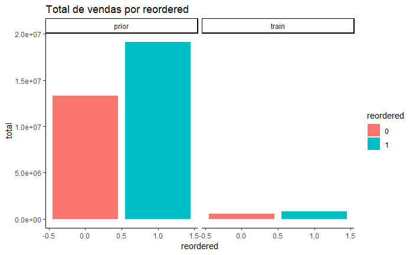

```r
# Agrupando os dados por reordered e dividindo os plots por eval_set
dataset %>% group_by(reordered, eval_set) %>%
  summarise(total = n()) %>%
  ggplot(aes(x = reordered, y = total, fill = factor(reordered))) +
  facet_wrap(. ~ eval_set) +
  geom_bar(stat = 'identity') +
  theme_classic() +
  ggtitle("Total de vendas por reordered") +
  labs(fill = "reordered")
```

Itens mais vendidos de acordo com o Departamento e se eram itens que o cliente já tinha comprado anteriormente ou não.

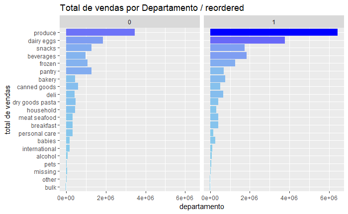

```r
# itens mais vendidos por departamento e recompra
dataset %>% group_by(department, reordered) %>%
  summarise(total = n()) %>%
  ggplot(aes(x = reorder(department, total), y = total, fill = total)) +
  geom_bar(stat = 'identity', show.legend = FALSE) +
  scale_fill_gradient(low='sky blue', high='blue') +
  coord_flip() +
  facet_grid(. ~ reordered) +
  theme_get() +
  xlab("total de vendas") + ylab('departamento') +
  ggtitle("Total de vendas por Departamento / reordered")
```

Total de vendas relativa por departamento.

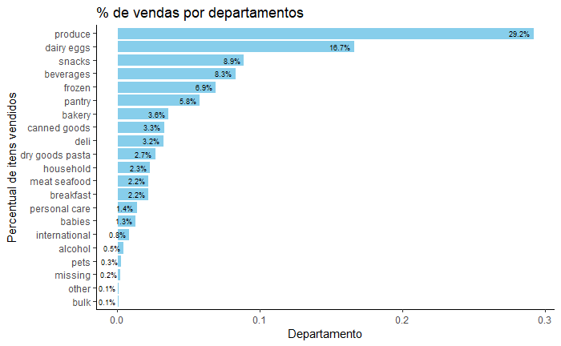

```r
# Agrupando os itens vendidos por departamento e criando um atributo para encontrar a venda relativa
dataset %>%
  group_by(department) %>%
  summarise(total = n()) %>%
  mutate(part = total / nrow(dataset)) %>%
  ggplot(mapping = aes(x = reorder(department, part), y = part)) +
  geom_bar(stat = 'identity', fill = 'sky blue', color = 'white') +
  geom_text(aes(label=scales::percent(part)), hjust=1.2, size = 2.5, color = 'black') +
  coord_flip() +
  theme_classic() +
  ylab("Departamento") + xlab("Percentual de itens vendidos") +
  ggtitle('% de vendas por departamentos')
```

10 Itens mais vendidos

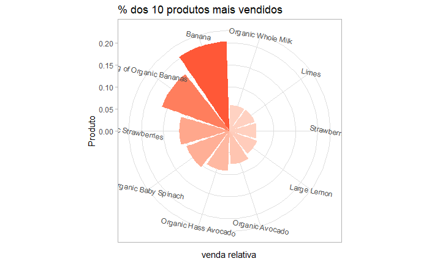

```r
# Plot com a venda relativa dos 10 itens com maior volume de vendas
dataset %>%
  group_by(product_name) %>%
  summarise(total = n()) %>%
  arrange(desc(total)) %>%
  top_n(10, total) %>%
  mutate(part = total / sum(total)) %>%
  ggplot(mapping = aes(x = reorder(product_name, part), y = part, fill = part)) +
  geom_bar(stat = 'identity',  show.legend = FALSE) +
  scale_fill_gradient(low='white', high='red', limits=c(0,.25)) +
  coord_polar() +
  theme_light() +
  theme(axis.text.x = element_text(angle=-10)) +
  ylab("Produto") + xlab("venda relativa") +
  ggtitle('% dos 10 produtos mais vendidos')
```

Top 10 de vendas de acordo com o corredor. Sendo os mais vendidos são as sessões de frutas e vegetais.

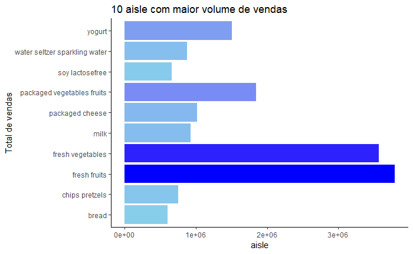

```r
# plotando os 10 itens mais vendidos de acordo com o atributo aisle
dataset %>% group_by(aisle) %>%
  summarise(compras = n()) %>%
  arrange(desc(compras)) %>%
  top_n(10, compras) %>%
  ggplot(aes(x = aisle, y = compras, fill = compras)) +
  geom_bar(stat = 'identity', show.legend = FALSE) +
  theme_classic() +
  coord_flip() +
  scale_fill_gradient(low='sky blue', high='blue') +
  ylab("aisle") + xlab("Total de vendas") +
  ggtitle('10 aisle com maior volume de vendas')
```

Venda relativa dos Top 10 em produtos, sendo os mais vendidos são frutas e vegetais.

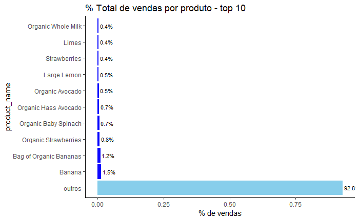

```r
# agrupando os dados por produtos e criando um cluster com o total dos demais itens
dataset %>% group_by(product_name) %>%
  summarise(vendas = n()) %>%
  arrange(desc(vendas)) %>%
  top_n(10, vendas) %>%
  bind_rows(
      dataset %>% group_by(product_name) %>%
        summarise(vendas = n()) %>%
        top_n(10, vendas) %>%
        summarise(vendas = sum(vendas)) %>%
        mutate(vendas = nrow(dataset) - vendas, product_name = 'outros') %>%
        select(product_name, everything())
  ) %>%
  mutate(part = vendas / sum(vendas)) %>%
  ggplot(aes(x = reorder(product_name, -part), y = part, fill = part)) +
  geom_bar(stat = 'identity', show.legend = FALSE) +
  geom_text(aes(label=scales::percent(part)), hjust=-0.1, size = 3, color = 'black') +
  coord_flip() +
  theme_classic() +
  scale_fill_gradient(low='blue', high=' sky blue') +
  ylab("% de vendas") + xlab("product_name") +
  ggtitle('% Total de vendas por produto - top 10')
```

Explorando os dados do dataset orders

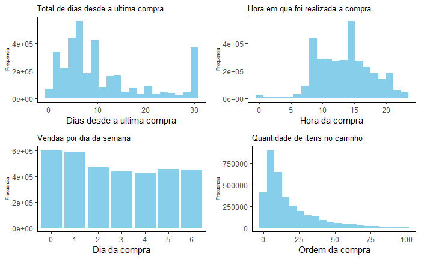

```r
# histograma com o total de dias desde a ultima compra
p1 <- ggplot(orders, aes(x = days_since_prior_order)) +
    geom_histogram(bins = 20, fill = 'sky blue') +
    theme_classic() +
    theme(plot.title = element_text(size = 10),
          axis.title.y = element_text(size = 6)) +
    ylab("Frequencia") + xlab("Dias desde a ultima compra") +
    ggtitle('Total de dias desde a ultima compra')

# histograma com as horas da compra
p2 <- ggplot(orders, aes(x = order_hour_of_day)) +
    geom_histogram(bins = 20, fill = 'sky blue') +
    theme_classic() +
    theme(plot.title = element_text(size = 10),
          axis.title.y = element_text(size = 6)) +
    ylab("Frequencia") + xlab("Hora da compra") +
    ggtitle('Hora em que foi realizada a compra')

# bar plot com as vendas por dia da semana
p3 <- ggplot(orders, aes(x = factor(order_dow))) +
    geom_bar(fill = 'sky blue') +
    theme_classic() +
    theme(plot.title = element_text(size = 10),
          axis.title.y = element_text(size = 6)) +
    ylab("Frequencia") + xlab("Dia da compra") +
    ggtitle('Vendaa por dia da semana')

# histograma com o total de itens no carringo de compras
p4 <- ggplot(orders, aes(x = order_number)) +
    geom_histogram(bins = 20, fill = 'sky blue') +
    theme_classic() +
    theme(plot.title = element_text(size = 10),
          axis.title.y = element_text(size = 6)) +
    ylab("Frequencia") + xlab("Ordem da compra") +
    ggtitle('Quantidade de itens no carrinho')

# plotando os resultados no mesmo grid
grid.arrange(p1, p2, p3, p4, ncol=2)
```

Vizivelmente as vendas se concentram no início da semana, sendo na segunda feira na parte da tarde e na terca no periodo da manhã.

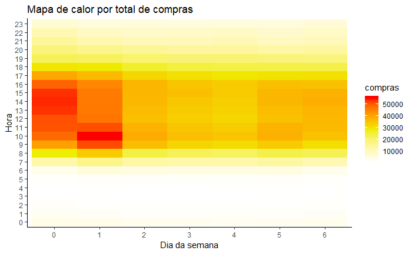

```r
# Gráfico de calor por total de vendas, hora e dia da compra.
orders %>% group_by(order_dow, order_hour_of_day) %>%
  summarise(compras = n()) %>%
  ggplot(aes(x = as.factor(order_dow), y = as.factor(order_hour_of_day))) +
  geom_raster(aes(fill = compras),interpolate = FALSE) +
  scale_fill_gradientn(colours=c("white","yellow2","red")) +
  theme_classic() +
  ylab("Hora") + xlab("Dia da semana") +
  ggtitle('Mapa de calor por total de compras')
```

### 5 - Criando cluster por tipo de cliente

Criando novos atributos de acordo com o dia da compra, horario, tempo desde a ultima compra, para clusterizar os tipos de clientes.

```r
# Agrupando os dados por cliente e criando novos atributos para clusterizar os dados
orders_cl <- orders %>% select(-c(order_id, eval_set, order_number)) %>%
  mutate(order_hour_of_day = if_else(order_hour_of_day < 12, 'manha', 'noite')) %>%
  mutate_at(vars(order_dow,order_hour_of_day), list(as.factor)) %>%
  dummy_cols() %>%
  group_by(user_id) %>%
  summarise('vendas' = n(),
            'd0' = sum(order_dow_0),
            'd1' = sum(order_dow_1),
            'd2' = sum(order_dow_2),
            'd3' = sum(order_dow_3),
            'd4' = sum(order_dow_4),
            'd5' = sum(order_dow_5),
            'd6' = sum(order_dow_6),
            'h_m' = sum(order_hour_of_day_manha),
            'h_n' = sum(order_hour_of_day_noite),
            'days_since_median' = mean(days_since_prior_order)) %>%
  mutate_at(vars(-user_id), list(scale))

# visualizando os dados para agrupamento
head(orders_cl)
```

| user_id | vendas | d0 | d1 | d2 | d3 | d4 | d5 | d6 | h_m | h_n | days_since_median |
| --- | --- | --- | --- | --- | --- | --- | --- | --- | --- | --- | --- |
| 1 | -0.33566155 | -0.7516610 | 0.0382683 | -0.08678325 | -0.03998631 | 0.64510923 | -0.66717635 | -0.6887537 | 0.1558561 | -0.6100154 | 0.6218405 |
| 2 | -0.09549016 | -0.7516610 | 0.7982864 | 0.89214647 | -0.03998631 | -0.35635875 | -0.36371918 | -0.6887537 | 0.9314029 | -0.7895335 | 0.2250161 |
| 3 | -0.21557586 | 0.7959973 | -0.2150711 | -0.41309316 | 0.29582606 | -0.69018141 | -0.36371918 | -0.6887537 | -0.7489486 | 0.1978160 | -0.4641127 |
| 4 | -0.63587578 | -0.7516610 | -0.7217498 | -0.73940307 | -0.37579868 | -0.02253609 | -0.06026202 | -0.3722663 | -0.4904330 | -0.6100154 | 0.2193026 |
| 5 | -0.69591862 | -0.2357749 | -0.4684104 | -0.73940307 | -0.03998631 | -0.69018141 | -0.66717635 | -0.6887537 | -0.6196908 | -0.6100154 | -0.5748656 |
| 6 | -0.75596147 | -0.7516610 | -0.7217498 | -0.41309316 | -0.37579868 | -0.35635875 | -0.36371918 | -0.6887537 | -0.7489486 | -0.6100154 | -0.3520414 |

Criando os clusters que variam de 10 a 50 e plotando a soma dentro dos quadrados, onde o numero de clusters escolhidos foi de 20.

```r
# criando um loop para coletar a soma dos quadrados de 10 a 50 clusters
totw <- NULL
ncluster <- 10:50

for (i in ncluster) {
  set.seed(124)
  totw <- append(totw, kmeans(orders_cl[,-1], centers = i,  iter.max = 100)$tot.withinss)
}
```

[output not shown]

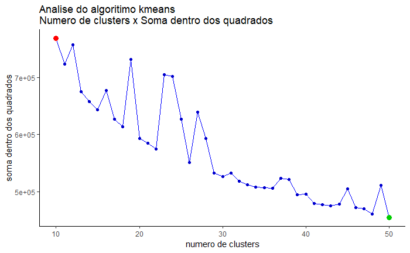

```r
# criando um dataframe para plotar os resultados
resultados <- data.frame("cluster" = ncluster, "withinss" = totw)

# plotando os resultados
resultados %>%
  mutate(Maior = ifelse(withinss == max(withinss), withinss, NA),
         Menor = ifelse(withinss == min(withinss), withinss, NA)) %>%
ggplot(aes(x = cluster, y = withinss)) +
  geom_line(color = 'blue') +
  geom_point(color = 'blue3') +
  geom_point(aes(y = Menor), color = 'green3', size = 3) +
  geom_point(aes(y = Maior), color = 'red', size = 3) +
  theme_classic() +
  ylab("soma dentro dos quadrados") + xlab("numero de clusters") +
  ggtitle("Analise do algoritimo kmeans \nNumero de clusters x Soma dentro dos quadrados")
```

### 6 - Analise exploratória dos clusters

Criando 20 clusters para o dataset ordes e plotando os grupos em um gráfico de dispersão, onde foi necessário separar em dois gráficos para facilitar a visualização.

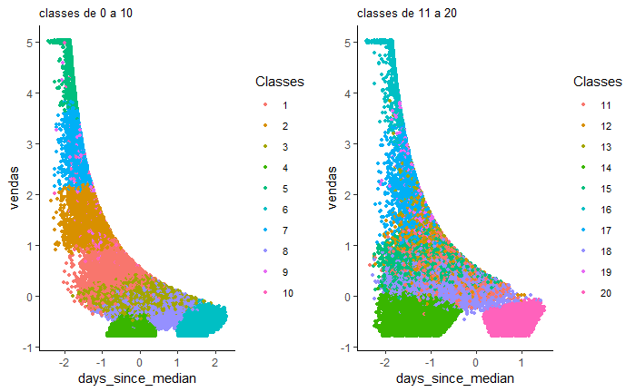

```r
# criando as 20 classes com o algoritimo kmeans
set.seed(124)
orders_cl$classes <- kmeans(orders_cl[,-1], centers = 20,  iter.max = 100)$cluster

# classes de 1 a 9
p1 <- orders_cl %>% filter(classes <= 10) %>%
ggplot(aes(x = days_since_median, y = vendas, colour = factor(classes))) +
  geom_point(size = 1, position = 'jitter') +
  theme_classic() +
  theme(plot.title = element_text(size = 10),
        legend.text = element_text(size = 8)) +
  ggtitle("classes de 0 a 10") +
  labs(colour = "Classes")

# classes de 10 a 20
p2 <- orders_cl %>% filter(classes > 10) %>%
ggplot(aes(x = days_since_median, y = vendas, colour = factor(classes))) +
  geom_point(size = 1, position = 'jitter') +
  theme_classic() +
  theme(plot.title = element_text(size = 10),
        legend.text = element_text(size = 8)) +
  ggtitle("classes de 11 a 20") +
  labs(colour = "Classes")

# Plotando as classes
grid.arrange(p1, p2, ncol = 2)
```

As classes 20, 6 e 4 possuem a maior quantidade de clientes

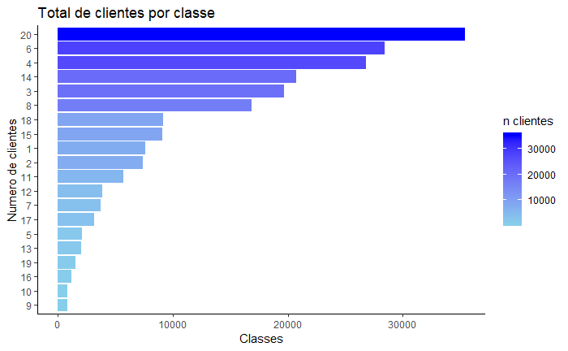

```r
# agrupando os dados por total de clientes em cada classe
orders_cl %>% group_by(classes) %>%
  summarise('clientes' = n_distinct(user_id)) %>%
  ggplot(aes(x = reorder(classes, clientes), y = clientes, fill = clientes)) +
  geom_bar(stat = 'identity') +
  coord_flip() +
  theme_classic() +
  scale_fill_gradient(low='sky blue', high='blue') +
  labs(fill = "n clientes") +
  ylab("Classes") + xlab("Numero de clientes") +
  ggtitle('Total de clientes por classe')
```

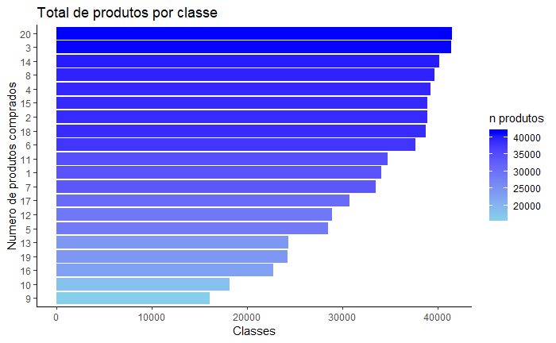

```r
# incluindo as classes aos dados de vendas
dataset <- orders %>% select(user_id, order_id) %>%
      inner_join(orders_cl, by = 'user_id') %>%
      select(order_id, classes) %>% right_join(dataset, by = 'order_id') %>%
      select(everything(), classes)

# plotanto o total de produtos por vendidos por classes
dataset %>% group_by(classes) %>%
  summarise('produtos' = n_distinct(product_id)) %>%
  ggplot(aes(x = reorder(classes, produtos), y = produtos, fill = produtos)) +
  geom_bar(stat = 'identity') +
  coord_flip() +
  theme_classic() +
  scale_fill_gradient(low='sky blue', high='blue') +
  labs(fill = "n produtos") +
  ylab("Classes") + xlab("Numero de produtos comprados") +
  ggtitle('Total de produtos por classe')
```

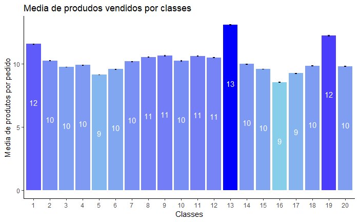

```r
# Agrupando os dados por classes e calculando a media de vendas
dataset %>% group_by(order_id, classes) %>%
  summarise(itens = n()) %>%
  group_by(classes) %>%
  summarise(media_itens = mean(itens),
            std_err = std.error(itens)) %>%
  ggplot(aes(x = factor(classes), y = media_itens, fill = media_itens)) +
  geom_bar(position = 'dodge', stat = 'identity', show.legend = FALSE) +
  geom_text(aes(label=round(media_itens,0)), vjust=10, size = 4, color = 'white') +
  geom_errorbar(aes(ymax = media_itens + std_err, ymin = media_itens - std_err), width = .1,
                position = position_dodge(.9)) +
  scale_fill_gradient(low='sky blue', high='blue') +
  theme_classic() +
  xlab('Classes') + ylab('Media de produtos por pedido') +
  ggtitle('Media de produdos vendidos por classes')
```

### 7 - Market Basket Analysis com o algoritimo Apriori

Gerando um dataset transacional com base nas vendas por produtos

```r
# criando um dataset com as transacoes
df_trans <- dataset %>% filter(eval_set == 'prior') %>%
  group_by(order_id) %>%
  summarise(itens = as.vector(list(product_name)))

# transformando para o formato transacional
df_trans <- as(df_trans$itens, 'transactions')

# resumo do dataset de transacoes
summary(df_trans)
```

```
transactions as itemMatrix in sparse format with
 3214874 rows (elements/itemsets/transactions) and
 49677 columns (items) and a density of 0.0002030896

most frequent items:
                Banana Bag of Organic Bananas   Organic Strawberries   Organic Baby Spinach
                472565                 379450                 264683                 241921
  Organic Hass Avocado                (Other)
                213584               30862286

element (itemset/transaction) length distribution:
sizes
     1      2      3      4      5      6      7      8      9     10     11     12     13     14     15     16
156748 186993 207027 222081 228330 227675 220006 203374 184347 165550 147461 131580 116871 103683  91644  81192
    17     18     19     20     21     22     23     24     25     26     27     28     29     30     31     32
 71360  62629  54817  48096  41863  36368  31672  27065  23613  20283  17488  15102  13033  11251   9571   8035
    33     34     35     36     37     38     39     40     41     42     43     44     45     46     47     48
  6991   6041   5164   4407   3681   3169   2653   2272   1978   1642   1412   1227   1048    895    743    608
    49     50     51     52     53     54     55     56     57     58     59     60     61     62     63     64
   563    491    394    348    288    275    224    175    159    165    119    121    100     79     67     57
    65     66     67     68     69     70     71     72     73     74     75     76     77     78     79     80
    53     49     44     39     24     33     30     23     22     24      9     11     15      9      7      7
    81     82     83     84     85     86     87     88     89     90     91     92     93     94     95     96
     5      9      4     10      5      7      4      7      4      1      4      9      4      1      4      3
    98     99    100    101    102    104    105    108    109    112    114    115    116    121    127    137
     4      2      4      2      3      2      1      2      2      1      1      1      1      1      1      1
   145
     1

   Min. 1st Qu.  Median    Mean 3rd Qu.    Max.
   1.00    5.00    8.00   10.09   14.00  145.00

includes extended item information - examples:
```

|  | labels |
| --- | --- |
| 1 | 'Swingtop' Premium Lager |
| 2 | #2 Coffee Filters |
| 3 | #2 Cone White Coffee Filters |

Visualizando as primeiras linhas dos dados de transações

```r
# Visualizando as primeiras transacoes
inspect(df_trans[1:3])
```

```
    items
[1] {All Natural No Stir Creamy Almond Butter,
     Carrots,
     Classic Blend Cole Slaw,
     Coconut Butter,
     Garlic Powder,
     Michigan Organic Kale,
     Natural Sweetener,
     Organic Egg Whites,
     Original Unflavored Gelatine Mix}
[2] {Air Chilled Organic Boneless Skinless Chicken Breasts,
     Lemons,
     Organic Baby Spinach,
     Organic Ezekiel 49 Bread Cinnamon Raisin,
     Organic Ginger Root,
     Total 2% with Strawberry Lowfat Greek Strained Yogurt,
     Unsweetened Almondmilk,
     Unsweetened Chocolate Almond Breeze Almond Milk}
[3] {Chewy 25% Low Sugar Chocolate Chip Granola,
     Energy Drink,
     Goldfish Cheddar Baked Snack Crackers,
     Honey/Lemon Cough Drops,
     Kellogg's Nutri-Grain Apple Cinnamon Cereal,
     Kellogg's Nutri-Grain Blueberry Cereal,
     Nutri-Grain Soft Baked Strawberry Cereal Breakfast Bars,
     Oats & Chocolate Chewy Bars,
     Original Orange Juice,
     Plain Pre-Sliced Bagels,
     Sugarfree Energy Drink,
     Tiny Twists Pretzels,
     Traditional Snack Mix}
```

visualizando os itens com maior frequência de vendas

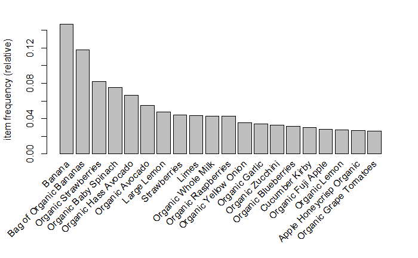

```r
# Plot com os 20 itens com a maior frequencia relativa
itemFrequencyPlot(df_trans,topN=20,type="relative")
```

Criando as regras de associação utilizando o algorítimo apriori, foi considerado um suporte mínimo de 0,001 e confiança de 0,25 e foram criadas 373 regras.

```r
# criando as regras
regras <- apriori(df_trans, parameter = list(sup = 0.001, conf = 0.25,  minlen= 2))
```

```
Apriori

Parameter specification:
```

|  | confidence | minval | smax | arem | aval | originalSupport | maxtime | support | minlen | maxlen | target | ext |
| --- | --- | --- | --- | --- | --- | --- | --- | --- | --- | --- | --- | --- |
|  | 0.25 | 0.1 | 1 | none | FALSE | TRUE | 5 | 0.001 | 2 | 10 | rules | FALSE |

```
Algorithmic control:
```

|  | filter | tree | heap | memopt | load | sort | verbose |
| --- | --- | --- | --- | --- | --- | --- | --- |
|  | 0.1 | TRUE | TRUE | FALSE | TRUE | 2 | TRUE |

```
Absolute minimum support count: 3214

set item appearances ...[0 item(s)] done [0.00s].
set transactions ...[49677 item(s), 3214874 transaction(s)] done [27.81s].
sorting and recoding items ... [1772 item(s)] done [0.50s].
creating transaction tree ... done [4.82s].
checking subsets of size 1 2 3 4 done [1.56s].
writing ... [373 rule(s)] done [0.01s].
creating S4 object  ... done [0.83s].
```

```r
inspect(regras[1:10])
```

```
     lhs                                           rhs                                                 support confidence      lift count
[1]  {Zero Calorie Cola}                        => {Soda}                                          0.001234885  0.4638934 41.668546  3970
[2]  {Apples}                                   => {Clementines}                                   0.001247016  0.3188072 33.230387  4009
[3]  {Lemon Sparkling Water}                    => {Grapefruit Sparkling Water}                    0.001037366  0.3512005 75.634068  3335
[4]  {Non Fat Acai & Mixed Berries Yogurt}      => {Icelandic Style Skyr Blueberry Non-fat Yogurt} 0.001220888  0.4531286 75.647888  3925
[5]  {Medium Navel Orange}                      => {Banana}                                        0.001012481  0.3268400  2.223503  3255
[6]  {Organic Plain Greek Whole Milk Yogurt}    => {Bag of Organic Bananas}                        0.001043276  0.2903393  2.459888  3354
[7]  {Mandarin Oranges}                         => {Banana}                                        0.001154011  0.3301299  2.245884  3710
[8]  {85% Lean Ground Beef}                     => {Banana}                                        0.001019947  0.2704776  1.840067  3279
[9]  {Nonfat Icelandic Style Strawberry Yogurt} => {Non Fat Raspberry Yogurt}                      0.001188538  0.3583419 70.344028  3821
[10] {Nonfat Icelandic Style Strawberry Yogurt} => {Vanilla Skyr Nonfat Yogurt}                    0.001212489  0.3655632 64.780041  3898
```